# Terns summer (Jun-Jul) breeding-adult mass trends

Issue #8 - follow-up to issue #5 task 3 / #6 / #7

2026-09-20

# 1 Background

All mass-trend work so far (#5 task 3, #6, #7) used **spring-caught** adults, with “confirmed breeder” status requiring a separate Jun/Jul sighting of the same ring in any year - a strict definition that leaves a fairly small sample, especially in recent years (spring coverage collapsed to 1-4% of birds caught by 2024-2026, see #7).

This script looks directly at adults caught **in the colony during the breeding season itself** (Jun-Jul). These are, by construction, all breeders - no non-breeder/passage-migrant ambiguity the way spring catches have - so **no breeder/non-breeder split is used**; per species this is a single “Summer adult” group. **Includes recaptures as well as new ringings** (previously issue #5 task 2 only used new ringings). Juveniles (age 3) are excluded, matching every other adult-mass metric in this repo.

# 2 Data loading

```r
raw_dir <- "../data_raw"
if (!dir.exists(raw_dir)) raw_dir <- "data_raw"
stopifnot(dir.exists(raw_dir))

proc_dir <- "../data_processed"
if (!dir.exists(proc_dir)) proc_dir <- "data_processed"

out_dir <- "../output"
if (!dir.exists(out_dir)) out_dir <- "output"

ringing_path <- file.path(raw_dir, "ringing_data_raw.xlsx")
stopifnot(file.exists(ringing_path))

col_names_47 <- c(
  "CR1","RingReplace","Rec","RingPrefix","RingNum","Species","Sex","Age","Wing","Weight",
  "Date","Time","Place","Lat","Lon","Ringer","Country","Remarks","Net","CR2","Subsp","Tail","Head",
  "Breeding","CP1","CP2","CP3","CP4","Colour","D","M","OrigDate","OrigCountry","OrigLat","OrigLon","OrigAge",
  "OldCR1","OldCR2","OldCR3","OldMetal1","OldMetal2","OilHead","OilWings","OilUpperP","OilUnderP","OilLegs","OilSum"
)
raw <- read_excel(ringing_path, sheet = "Data", skip = 2, col_names = col_names_47)

terns <- raw %>%
  filter(Species %in% c("STEALB", "STEHIR")) %>%
  mutate(
    year = year(Date),
    month = month(Date),
    is_new = is.na(Rec) | trimws(Rec) == "",
    is_recap = trimws(Rec) == "R" & !is.na(Rec),
    is_capture = is_new | is_recap,  # excludes foreign-scheme codes (distant reports, not in-hand)
    species_label = ifelse(Species == "STEHIR", "Common Tern", "Little Tern")
  )
```

# 3 Building the summer-adult group

```r
juvenile_ages <- c(1, 3)
summer_adults_raw <- terns %>%
  filter(is_capture, !(Age %in% juvenile_ages), !is.na(Weight), month %in% 6:7) %>%
  mutate(group = "Summer adult")

n_before <- nrow(summer_adults_raw)
summer_adults <- summer_adults_raw %>% filter(!is.na(Wing))
n_after <- nrow(summer_adults)

cat("Jun-Jul adult records with Weight:", n_before, "- also with Wing:", n_after,
    sprintf("(%.1f%% retained)\n", 100 * n_after / n_before))
```

```
## Jun-Jul adult records with Weight: 1991 - also with Wing: 1966 (98.7% retained)
```

```r
kable(
  summer_adults %>% group_by(species_label) %>%
    summarise(n = n(), n_years = n_distinct(year),
              min_year = min(year), max_year = max(year), .groups = "drop"),
  caption = "Summer-adult weighed records by species"
)
```

Summer-adult weighed records by species

| species_label | n | n_years | min_year | max_year |
| --- | --- | --- | --- | --- |
| Common Tern | 1283 | 16 | 2010 | 2026 |
| Little Tern | 683 | 17 | 2010 | 2026 |

```r
kable(
  summer_adults %>% count(species_label, year, name = "n") %>%
    pivot_wider(names_from = species_label, values_from = n, values_fill = 0),
  caption = "Sample size by year and species"
)
```

Sample size by year and species

| year | Common Tern | Little Tern |
| --- | --- | --- |
| 2010 | 62 | 63 |
| 2011 | 121 | 21 |
| 2012 | 79 | 27 |
| 2013 | 38 | 37 |
| 2014 | 53 | 57 |
| 2015 | 51 | 71 |
| 2016 | 117 | 71 |
| 2017 | 119 | 58 |
| 2018 | 45 | 48 |
| 2019 | 76 | 44 |
| 2020 | 204 | 62 |
| 2021 | 58 | 14 |
| 2022 | 86 | 51 |
| 2023 | 48 | 17 |
| 2024 | 44 | 11 |
| 2026 | 82 | 23 |
| 2025 | 0 | 8 |

# 4 Two normalization methods

Same approach as #6: **simple ratio** (`Weight/Wing`) and **SMI** (scaled mass index, Peig & Green 2009 - log-log SMA regression). Both fit **per species** (no group split needed here, since there’s only one group per species).

```r
compute_smi <- function(df) {
  lx <- log(df$Wing)
  ly <- log(df$Weight)
  b <- sd(ly) / sd(lx)  # SMA slope
  wing_mean <- mean(df$Wing)
  df$smi <- df$Weight * (wing_mean / df$Wing) ^ b
  df$smi_b <- b
  df
}

summer_adults <- summer_adults %>%
  mutate(mass_ratio = Weight / Wing) %>%
  group_by(species_label) %>%
  group_modify(~ compute_smi(.x)) %>%
  ungroup()

kable(
  summer_adults %>% distinct(species_label, smi_b),
  digits = 3, caption = "SMA slope (b) used for SMI, by species"
)
```

SMA slope (b) used for SMI, by species

| species_label | smi_b |
| --- | --- |
| Common Tern | 3.048 |
| Little Tern | 2.876 |

# 5 Trend statistics, all three metrics

```r
format_pval <- function(p) {
  ifelse(p < 0.001, formatC(p, format = "e", digits = 2), formatC(p, format = "f", digits = 3))
}

fit_trend <- function(df, response) {
  df %>%
    group_by(species_label) %>%
    group_modify(~ {
      m <- lm(reformulate("year", response = response), data = .x)
      s <- summary(m)
      tibble(
        n = nrow(.x),
        n_years = n_distinct(.x$year),
        slope_per_year = round(coef(m)["year"], 4),
        se = round(s$coefficients["year", "Std. Error"], 4),
        p_value = signif(s$coefficients["year", "Pr(>|t|)"], 3),
        r_squared = round(s$r.squared, 3)
      )
    }) %>%
    ungroup() %>%
    mutate(metric = response)
}

trend_stats <- bind_rows(
  fit_trend(summer_adults, "Weight"),
  fit_trend(summer_adults, "mass_ratio"),
  fit_trend(summer_adults, "smi")
) %>%
  mutate(metric = recode(metric, Weight = "Raw mass (g)",
                          mass_ratio = "Mass/Wing ratio",
                          smi = "SMI (g, rescaled)"),
         metric = factor(metric, levels = c("Raw mass (g)", "Mass/Wing ratio", "SMI (g, rescaled)"))) %>%
  arrange(species_label, metric)

trend_stats_display <- trend_stats %>%
  mutate(significant = p_value < 0.05, p_value_fmt = format_pval(p_value)) %>%
  mutate(p_value_fmt = ifelse(significant, paste0("<strong>", p_value_fmt, "</strong>"), p_value_fmt)) %>%
  select(species_label, metric, n, n_years, slope_per_year, se, p_value = p_value_fmt, r_squared)

kable(trend_stats_display, escape = FALSE,
      caption = "value ~ year regression, by species/metric (significant rows, p&lt;0.05, in bold)")
```

value ~ year regression, by species/metric (significant rows, p<0.05, in bold)

| species_label | metric | n | n_years | slope_per_year | se | p_value | r_squared |
| --- | --- | --- | --- | --- | --- | --- | --- |
| Common Tern | Raw mass (g) | 1283 | 16 | 0.0144 | 0.0557 | 0.796 | 0.000 |
| Common Tern | Mass/Wing ratio | 1283 | 16 | 0.0002 | 0.0002 | 0.452 | 0.000 |
| Common Tern | SMI (g, rescaled) | 1283 | 16 | 0.0890 | 0.0673 | 0.186 | 0.001 |
| Little Tern | Raw mass (g) | 683 | 17 | 0.0283 | 0.0322 | 0.380 | 0.001 |
| Little Tern | Mass/Wing ratio | 683 | 17 | 0.0002 | 0.0002 | 0.194 | 0.002 |
| Little Tern | SMI (g, rescaled) | 683 | 17 | 0.0661 | 0.0405 | 0.103 | 0.004 |

# 6 Visual comparison

Per-year mean shown as a point, with the **sample size (n) printed below each point** - year-to-year coverage varies, and that should stay visible rather than being smoothed over. Trend line fit on individual-level records (not the per-year means), same convention as `03_mass_trends.Rmd`, and only drawn where the year slope is significant (p<0.05).

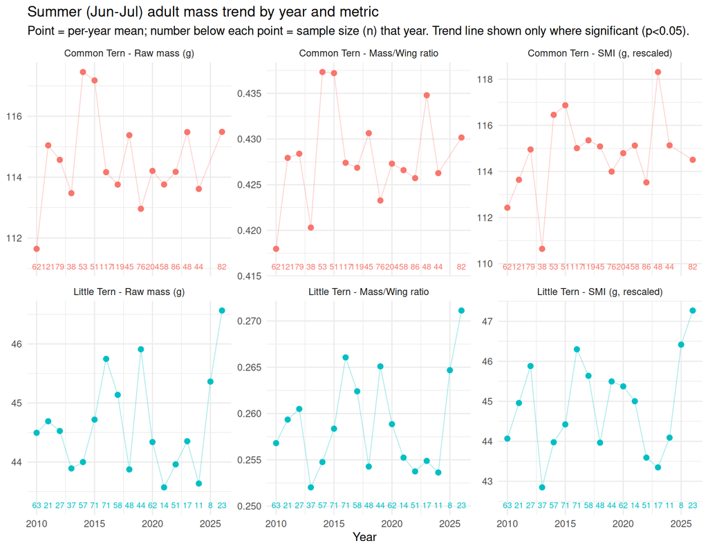

```r
panel_levels <- c("Common Tern - Raw mass (g)", "Common Tern - Mass/Wing ratio", "Common Tern - SMI (g, rescaled)",
                   "Little Tern - Raw mass (g)", "Little Tern - Mass/Wing ratio", "Little Tern - SMI (g, rescaled)")

yearly_means <- summer_adults %>%
  pivot_longer(cols = c(Weight, mass_ratio, smi), names_to = "metric", values_to = "value") %>%
  mutate(metric = recode(metric, Weight = "Raw mass (g)",
                          mass_ratio = "Mass/Wing ratio",
                          smi = "SMI (g, rescaled)"),
         panel_label = factor(paste(species_label, metric, sep = " - "), levels = panel_levels)) %>%
  group_by(species_label, metric, panel_label, year) %>%
  summarise(mean_value = mean(value), n = n(), .groups = "drop")

individual_long <- summer_adults %>%
  pivot_longer(cols = c(Weight, mass_ratio, smi), names_to = "metric", values_to = "value") %>%
  mutate(metric = recode(metric, Weight = "Raw mass (g)",
                          mass_ratio = "Mass/Wing ratio",
                          smi = "SMI (g, rescaled)"),
         panel_label = factor(paste(species_label, metric, sep = " - "), levels = panel_levels))

sig_combos <- trend_stats %>% filter(p_value < 0.05) %>%
  mutate(metric = as.character(metric)) %>%
  distinct(species_label, metric)
individual_long_sig <- individual_long %>%
  mutate(metric = as.character(metric)) %>%
  semi_join(sig_combos, by = c("species_label", "metric"))

# n-count labels placed just below each panel's data range so they don't
# overlap the points/line, independent per panel (free_y scales).
label_pos <- yearly_means %>%
  group_by(panel_label) %>%
  mutate(y_label = min(mean_value) - 0.1 * (max(mean_value) - min(mean_value))) %>%
  ungroup()

ggplot(yearly_means, aes(year, mean_value, color = species_label)) +
  geom_point(size = 2) +
  geom_line(alpha = 0.3, linewidth = 0.4) +
  geom_smooth(data = individual_long_sig, aes(x = year, y = value), method = "lm", se = FALSE, linewidth = 0.8) +
  geom_text(data = label_pos, aes(y = y_label, label = n), size = 2.6, show.legend = FALSE) +
  facet_wrap(~panel_label, ncol = 3, scales = "free_y") +
  guides(color = "none") +
  labs(title = "Summer (Jun-Jul) adult mass trend by year and metric",
       subtitle = "Point = per-year mean; number below each point = sample size (n) that year. Trend line shown only where significant (p<0.05).",
       y = NULL, x = "Year") +
  theme_minimal()
```

# 7 Save outputs

```r
write.csv(summer_adults %>% select(-smi_b),
          file.path(proc_dir, "summer_breeder_mass_records.csv"), row.names = FALSE)
write.csv(trend_stats, file.path(proc_dir, "summer_breeder_mass_trends_stats.csv"), row.names = FALSE)
cat("Wrote data_processed/summer_breeder_mass_records.csv and summer_breeder_mass_trends_stats.csv\n")
```

```
## Wrote data_processed/summer_breeder_mass_records.csv and summer_breeder_mass_trends_stats.csv
```